# Personal Loan Campaign - Connie Xavier

```
Training performance:
```

|  | Accuracy | Recall | Precision | F1 |
| --- | --- | --- | --- | --- |
| 0 | 0.922571 | 0.883929 | 0.561437 | 0.686705 |

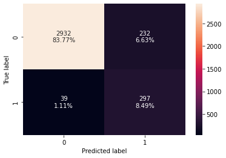

```python
# checking training performance for this model
log_reg_model_train_perf_threshold_auc_roc = model_performance_classification_sklearn_with_threshold(
    lg, X_train, y_train, threshold=optimal_threshold_auc_roc
)
# creating confusion matrix
confusion_matrix_sklearn_with_threshold(
    lg, X_train, y_train, threshold=optimal_threshold_auc_roc
)
print("Training performance:")
log_reg_model_train_perf_threshold_auc_roc
```

```
Test performance:
```

|  | Accuracy | Recall | Precision | F1 |
| --- | --- | --- | --- | --- |
| 0 | 0.913333 | 0.861111 | 0.529915 | 0.656085 |

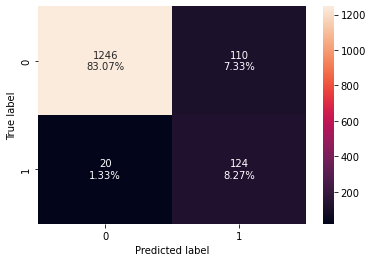

```python
# checking test performance
log_reg_model_test_perf_threshold_auc_roc = model_performance_classification_sklearn_with_threshold(
    lg, X_test, y_test, threshold=optimal_threshold_auc_roc
)
# creating confusion matrix
confusion_matrix_sklearn_with_threshold(
    lg, X_test, y_test, threshold=optimal_threshold_auc_roc
)
print("Test performance:")
log_reg_model_test_perf_threshold_auc_roc
```

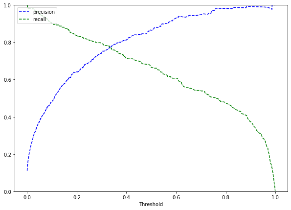

```python
# Let's use Precision-Recall curve and see if we can find a better threshold
y_scores = lg.predict_proba(X_train)[:, 1]
prec, rec, tre = precision_recall_curve(y_train, y_scores,)


def plot_prec_recall_vs_tresh(precisions, recalls, thresholds):
    plt.plot(thresholds, precisions[:-1], "b--", label="precision")
    plt.plot(thresholds, recalls[:-1], "g--", label="recall")
    plt.xlabel("Threshold")
    plt.legend(loc="upper left")
    plt.ylim([0, 1])


plt.figure(figsize=(10, 7))
plot_prec_recall_vs_tresh(prec, rec, tre)
plt.show()
```

```python
# determine threshold where precision = recall
t = pd.DataFrame([tre, prec, rec]).T
t[t[1] == t[2]][0]
```

```
2655    0.334122
Name: 0, dtype: float64
```

- Selecting value around 0.28 will provide a higher recall and a good precision.

```python
# setting the threshold
optimal_threshold_curve = 0.28
```

```
Training performance:
```

|  | Accuracy | Recall | Precision | F1 |
| --- | --- | --- | --- | --- |
| 0 | 0.951429 | 0.797619 | 0.724324 | 0.759207 |

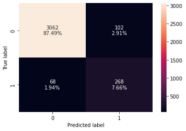

```python
# check training performance
log_reg_model_train_perf_threshold_curve = model_performance_classification_sklearn_with_threshold(
    lg, X_train, y_train, threshold=optimal_threshold_curve
)
# creating confusion matrix
confusion_matrix_sklearn_with_threshold(
    lg, X_train, y_train, threshold=optimal_threshold_curve
)
print("Training performance:")
log_reg_model_train_perf_threshold_curve
```

```
Test performance:
```

|  | Accuracy | Recall | Precision | F1 |
| --- | --- | --- | --- | --- |
| 0 | 0.946 | 0.770833 | 0.698113 | 0.732673 |

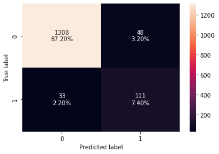

```python
# checking test performance
log_reg_model_test_perf_threshold_curve = model_performance_classification_sklearn_with_threshold(
    lg, X_test, y_test, threshold=optimal_threshold_curve
)
# creating confusion matrix
confusion_matrix_sklearn_with_threshold(
    lg, X_test, y_test, threshold=optimal_threshold_curve
)
print("Test performance:")
log_reg_model_test_perf_threshold_curve
```

- The model gives better performance on Recall than the initial model.

```python
# training performance comparison for all models

models_train_comp_df = pd.concat(
    [
        log_reg_model_train_perf.T,
        log_reg_model_train_perf_threshold_auc_roc.T,
        log_reg_model_train_perf_threshold_curve.T,
    ],
    axis=1,
)
models_train_comp_df.columns = [
    "Logistic Regression sklearn",
    "Logistic Regression-ROC Threshold",
    "Logistic Regression-P-R Threshold",
]

print("Training performance comparison:")
models_train_comp_df
```

```
Training performance comparison:
```

|  | Logistic Regression sklearn | Logistic Regression-ROC Threshold | Logistic Regression-P-R Threshold |
| --- | --- | --- | --- |
| Accuracy | 0.957714 | 0.922571 | 0.951429 |
| Recall | 0.663690 | 0.883929 | 0.797619 |
| Precision | 0.864341 | 0.561437 | 0.724324 |
| F1 | 0.750842 | 0.686705 | 0.759207 |

```python
# testing performance comparison for all models

models_test_comp_df = pd.concat(
    [
        log_reg_model_test_perf.T,
        log_reg_model_test_perf_threshold_auc_roc.T,
        log_reg_model_test_perf_threshold_curve.T,
    ],
    axis=1,
)
models_test_comp_df.columns = [
    "Logistic Regression sklearn",
    "Logistic Regression-ROC Threshold",
    "Logistic Regression-P-R Threshold",
]

print("Test set performance comparison:")
models_test_comp_df
```

```
Test set performance comparison:
```

|  | Logistic Regression sklearn | Logistic Regression-ROC Threshold | Logistic Regression-P-R Threshold |
| --- | --- | --- | --- |
| Accuracy | 0.957333 | 0.913333 | 0.946000 |
| Recall | 0.645833 | 0.861111 | 0.770833 |
| Precision | 0.877358 | 0.529915 | 0.698113 |
| F1 | 0.744000 | 0.656085 | 0.732673 |

- The model using the threshold from the ROC-AUC curve had the highest recall score of training and test set.
- The model using the threshold from the Precision-Recall curve had a fairly high recall score without compromising too much on precision.

Let us see which variables are the most important in the model.

```python
# converting coefficients to odds
odds = np.exp(lg.coef_[0])

# finding the percentage change
perc_change_odds = (np.exp(lg.coef_[0]) - 1) * 100

# removing limit from number of columns to display
pd.set_option("display.max_columns", None)

# adding the odds to a dataframe
pd.DataFrame({"Odds": odds, "Change_odd%": perc_change_odds}, index=X_train.columns).T
```

|  | Family | Securities_Account | CD_Account | Online | CreditCard | Age_std | Income_std | CCAvg_std | Mortgage_std | Education_2 | Education_3 |
| --- | --- | --- | --- | --- | --- | --- | --- | --- | --- | --- | --- |
| Odds | 1.762048 | 0.666311 | 22.221928 | 0.565040 | 0.426096 | 1.061020 | 13.459761 | 1.274909 | 1.088201 | 31.667133 | 33.226737 |
| Change_odd% | 76.204830 | -33.368854 | 2122.192814 | -43.496046 | -57.390384 | 6.101969 | 1245.976134 | 27.490880 | 8.820123 | 3066.713272 | 3222.673667 |

### Coefficient interpretations

- `Income_std`: Holding all other features constant a unit change in Income (standardized) will increase the odds of a customer taking a loan by 13.5 times or a 1246% increase in the odds.
- `CD_Account`: The odds of a customer with a CD account taking a loan is 22 times more than a customer without a CD account or 2122% more odds.
- Based on the % change in odds, graduate or advanced degree, Income, and having a CD account are the most significant variables for determining whether a customer will take a loan.

## Part 5: Decision Tree Model Building

```python
# decision trees do not require as much data preprocessing as logistic regression
df_dt = df1.copy()  # dt will stand for decision tree
# we will treat Education as categorical
df_dt[["Education"]] = df_dt[["Education"]].astype("category")
```

```python
# get X and Y variables
X = df_dt.drop(["Personal_Loan"], axis=1)
Y = df_dt["Personal_Loan"]

# get dummy variables
X = pd.get_dummies(X, drop_first=True)

# Splitting data in train and test sets
X_train, X_test, y_train, y_test = train_test_split(
    X, Y, test_size=0.30, random_state=101, stratify=Y
)
```

```python
# verify that training and test sets have same distribution of 0s and 1s
print("Shape of Training set : ", X_train.shape)
print("Shape of test set : ", X_test.shape)
print("Percentage of classes in training set:")
print(y_train.value_counts(normalize=True))
print("Percentage of classes in test set:")
print(y_test.value_counts(normalize=True))
```

```
Shape of Training set :  (3500, 49)
Shape of test set :  (1500, 49)
Percentage of classes in training set:
0    0.904
1    0.096
Name: Personal_Loan, dtype: float64
Percentage of classes in test set:
0    0.904
1    0.096
Name: Personal_Loan, dtype: float64
```

- Training and test set have the same split of the dependent variable.

```python
##  Function to calculate recall score
def get_recall_score(model, predictors, target):
    """
    model: classifier
    predictors: independent variables
    target: dependent variable

    """
    prediction = model.predict(predictors)
    return recall_score(target, prediction)
```

```python
##  Function to show confusion matrix
def confusion_matrix_sklearn(model, predictors, target):
    """
    To plot the confusion_matrix with percentages

    model: classifier
    predictors: independent variables
    target: dependent variable
    """
    y_pred = model.predict(predictors)
    cm = confusion_matrix(target, y_pred)
    labels = np.asarray(
        [
            ["{0:0.0f}".format(item) + "\n{0:.2%}".format(item / cm.flatten().sum())]
            for item in cm.flatten()
        ]
    ).reshape(2, 2)

    plt.figure(figsize=(6, 4))
    sns.heatmap(cm, annot=labels, fmt="")
    plt.ylabel("True label")
    plt.xlabel("Predicted label")
```

```python
# create basic model and fit training data
model = DecisionTreeClassifier(
    criterion="gini", class_weight="balanced", random_state=101
)
model.fit(X_train, y_train)
```

```
DecisionTreeClassifier(class_weight='balanced', random_state=101)
```

```
Recall Score: 1.0
```

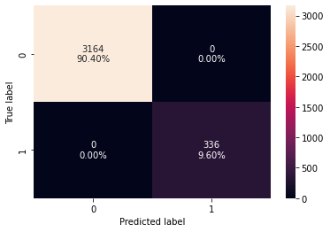

```python
# performance on training set
confusion_matrix_sklearn(model, X_train, y_train)
decision_tree_perf_train = get_recall_score(model, X_train, y_train)
print("Recall Score:", decision_tree_perf_train)
```

```
Recall Score: 0.9375
```

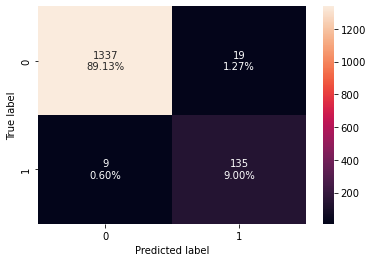

```python
# performance on test set
confusion_matrix_sklearn(model, X_test, y_test)
decision_tree_perf_test = get_recall_score(model, X_test, y_test)
print("Recall Score:", decision_tree_perf_test)
```

- There is a difference in performance of model on training set and test set, which suggests that the model is overfiiting to the training data.

#### Reducing Overfitting with Pre-pruning

```python
# Choose the type of classifier.
estimator = DecisionTreeClassifier(random_state=101, class_weight="balanced")

# Grid of parameters to choose from
parameters = {
    "max_depth": [5, 10, 15, None],
    "criterion": ["entropy", "gini"],
    "splitter": ["best", "random"],
    "min_impurity_decrease": [0.00001, 0.0001, 0.01],
}

# Type of scoring used to compare parameter combinations
scorer = make_scorer(recall_score)

# Run the grid search
grid_obj = GridSearchCV(estimator, parameters, scoring=scorer, cv=5)
grid_obj = grid_obj.fit(X_train, y_train)

# Set the clf to the best combination of parameters
estimator = grid_obj.best_estimator_

# Fit the best algorithm to the data.
estimator.fit(X_train, y_train)
```

```
DecisionTreeClassifier(class_weight='balanced', max_depth=5,
                       min_impurity_decrease=0.01, random_state=101)
```

```
Recall Score: 0.9880952380952381
```

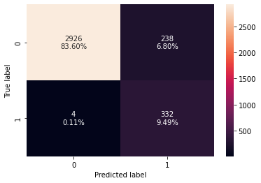

```python
# plot results from training data
confusion_matrix_sklearn(estimator, X_train, y_train)
decision_tree_tune_perf_train = get_recall_score(estimator, X_train, y_train)
print("Recall Score:", decision_tree_tune_perf_train)
```

```
Recall Score: 0.9861111111111112
```

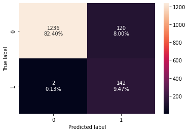

```python
# plot results from testing data
confusion_matrix_sklearn(estimator, X_test, y_test)
decision_tree_tune_perf_test = get_recall_score(estimator, X_test, y_test)
print("Recall Score:", decision_tree_tune_perf_test)
```

- The model is giving a generalized result now as performance on training and test set are very similar. The results are very close to 1.

#### Try to improve performance with post-pruning (cost complexity pruning)

```python
clf = DecisionTreeClassifier(random_state=101, class_weight="balanced")
path = clf.cost_complexity_pruning_path(X_train, y_train)
ccp_alphas, impurities = path.ccp_alphas, path.impurities
```

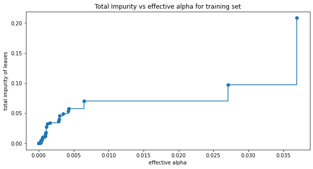

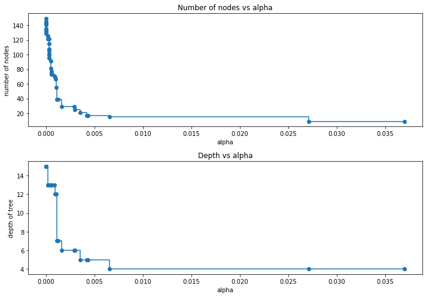

```python
# plot alpha against multiple variables
fig, ax = plt.subplots(figsize=(10, 5))
ax.plot(ccp_alphas[:-1], impurities[:-1], marker="o", drawstyle="steps-post")
ax.set_xlabel("effective alpha")
ax.set_ylabel("total impurity of leaves")
ax.set_title("Total Impurity vs effective alpha for training set")
plt.show()

clfs = []
for ccp_alpha in ccp_alphas:
    clf = DecisionTreeClassifier(
        random_state=1, ccp_alpha=ccp_alpha, class_weight="balanced"
    )
    clf.fit(X_train, y_train)
    clfs.append(clf)

clfs = clfs[:-1]
ccp_alphas = ccp_alphas[:-1]

node_counts = [clf.tree_.node_count for clf in clfs]
depth = [clf.tree_.max_depth for clf in clfs]
fig, ax = plt.subplots(2, 1, figsize=(10, 7))
ax[0].plot(ccp_alphas, node_counts, marker="o", drawstyle="steps-post")
ax[0].set_xlabel("alpha")
ax[0].set_ylabel("number of nodes")
ax[0].set_title("Number of nodes vs alpha")
ax[1].plot(ccp_alphas, depth, marker="o", drawstyle="steps-post")
ax[1].set_xlabel("alpha")
ax[1].set_ylabel("depth of tree")
ax[1].set_title("Depth vs alpha")
fig.tight_layout()
```

- As alpha increases, the total impurity increases while the number of nodes and depth of tree decrease.

```python
# calculate recall scores for training data
recall_train = []
for clf in clfs:
    pred_train = clf.predict(X_train)
    values_train = recall_score(y_train, pred_train)
    recall_train.append(values_train)
```

```python
# calculate recall scores for testing data
recall_test = []
for clf in clfs:
    pred_test = clf.predict(X_test)
    values_test = recall_score(y_test, pred_test)
    recall_test.append(values_test)
```

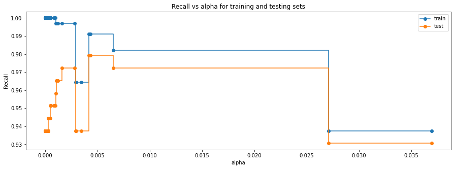

```python
# plot train and test recall scores
fig, ax = plt.subplots(figsize=(15, 5))
ax.set_xlabel("alpha")
ax.set_ylabel("Recall")
ax.set_title("Recall vs alpha for training and testing sets")
ax.plot(
    ccp_alphas, recall_train, marker="o", label="train", drawstyle="steps-post",
)
ax.plot(ccp_alphas, recall_test, marker="o", label="test", drawstyle="steps-post")
ax.legend()
plt.show()
```

```python
# creating the model where we get highest train and test recall
best_model = DecisionTreeClassifier(
    ccp_alpha=0.005, class_weight="balanced", random_state=101
)
best_model.fit(X_train, y_train)
```

```
DecisionTreeClassifier(ccp_alpha=0.005, class_weight='balanced',
                       random_state=101)
```

```
Recall Score: 0.9821428571428571
```

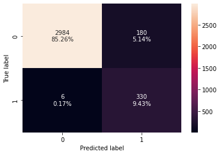

```python
# checking performance on training set
confusion_matrix_sklearn(best_model, X_train, y_train)
decision_tree_postpruned_perf_train = get_recall_score(best_model, X_train, y_train)
print("Recall Score:", decision_tree_postpruned_perf_train)
```

```
Recall Score: 0.9722222222222222
```

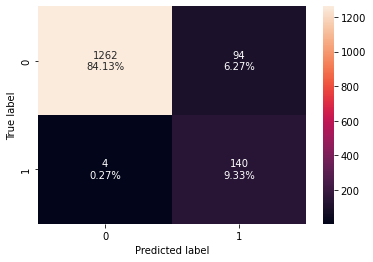

```python
# checking performance on test set
confusion_matrix_sklearn(best_model, X_test, y_test)
decision_tree_postpruned_perf_test = get_recall_score(best_model, X_test, y_test)
print("Recall Score:", decision_tree_postpruned_perf_test)
```

- The results have improved from the initial model.
- The performance is comparable to the hyperparameter tuned model for recall results.
- The model is giving a generalized performance on training and test set.

We will procede with using the hyperparameter tuned model as it gave the best results. We will determine the important features from this model and visualize the tree.

```python
# get feature importances
print(
    pd.DataFrame(
        estimator.feature_importances_, columns=["Imp"], index=X_train.columns
    ).sort_values(by="Imp", ascending=False)
)
```

```
                                    Imp
Income                         0.678779
Education_2                    0.160336
CCAvg                          0.063137
Education_3                    0.059876
Family                         0.037871
Age                            0.000000
County_Santa Barbara County    0.000000
County_Sacramento County       0.000000
County_San Benito County       0.000000
County_San Bernardino County   0.000000
County_San Diego County        0.000000
County_San Francisco County    0.000000
County_San Joaquin County      0.000000
County_San Luis Obispo County  0.000000
County_San Mateo County        0.000000
County_Shasta County           0.000000
County_Santa Clara County      0.000000
County_Santa Cruz County       0.000000
County_Placer County           0.000000
County_Siskiyou County         0.000000
County_Solano County           0.000000
County_Sonoma County           0.000000
County_Stanislaus County       0.000000
County_Trinity County          0.000000
County_Tuolumne County         0.000000
County_Ventura County          0.000000
County_Riverside County        0.000000
County_Napa County             0.000000
County_Orange County           0.000000
County_Fresno County           0.000000
Mortgage                       0.000000
Securities_Account             0.000000
CD_Account                     0.000000
Online                         0.000000
CreditCard                     0.000000
County_Butte County            0.000000
County_Contra Costa County     0.000000
County_El Dorado County        0.000000
County_Humboldt County         0.000000
County_None                    0.000000
County_Imperial County         0.000000
County_Kern County             0.000000
County_Lake County             0.000000
County_Los Angeles County      0.000000
County_Marin County            0.000000
County_Mendocino County        0.000000
County_Merced County           0.000000
County_Monterey County         0.000000
County_Yolo County             0.000000
```

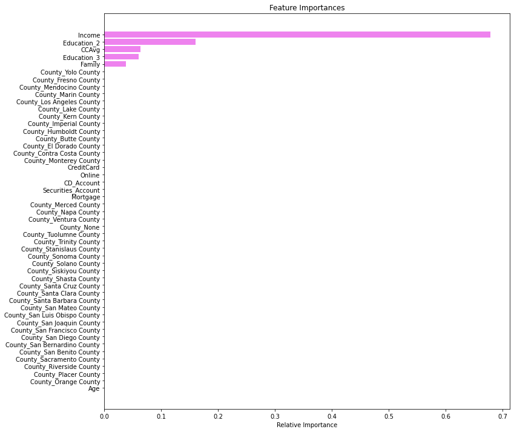

```python
# visualize the feature importances
## creating a list of column names
feature_names = X_train.columns.to_list()
importances = estimator.feature_importances_
indices = np.argsort(importances)

plt.figure(figsize=(12, 12))
plt.title("Feature Importances")
plt.barh(range(len(indices)), importances[indices], color="violet", align="center")
plt.yticks(range(len(indices)), [feature_names[i] for i in indices])
plt.xlabel("Relative Importance")
plt.show()
```

- Income is the most important feature in the model, by far. Family, Education, and CCAvg follow. All other features are not important.

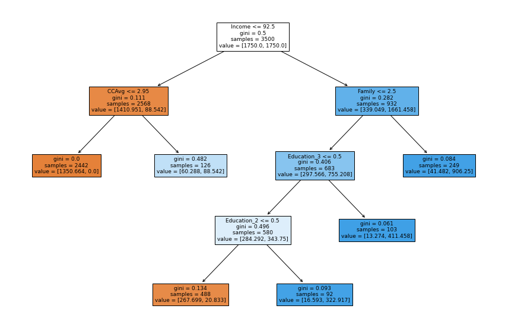

```python
# visualize the tree
plt.figure(figsize=(15, 10))
out = tree.plot_tree(
    estimator,
    feature_names=feature_names,
    filled=True,
    fontsize=9,
    node_ids=False,
    class_names=None,
)
for o in out:
    arrow = o.arrow_patch
    if arrow is not None:
        arrow.set_edgecolor("black")
        arrow.set_linewidth(1)
plt.show()
```

- A customer with an income greater than $92,500, family greater than 2.5, and has an advanced degree, is more likely to purchase a loan.

## Part 6: Comparing models

We will compare the best logistic regression model with the best decision tree model.

```python
# calculate metrics for the best decision tree model on the training and test set
dec_tree_model_train_perf = model_performance_classification_sklearn_with_threshold(
    estimator, X_train, y_train
)
dec_tree_model_test_perf = model_performance_classification_sklearn_with_threshold(
    estimator, X_test, y_test
)
```

```python
# training performance comparison

models_train_comp_df = pd.concat(
    [log_reg_model_train_perf_threshold_auc_roc.T, dec_tree_model_train_perf.T,],
    axis=1,
)
models_train_comp_df.columns = [
    "Logistic Regression-ROC Threshold",
    "Decision Tree",
]

print("Training performance comparison:")
models_train_comp_df
```

```
Training performance comparison:
```

|  | Logistic Regression-ROC Threshold | Decision Tree |
| --- | --- | --- |
| Accuracy | 0.922571 | 0.930857 |
| Recall | 0.883929 | 0.988095 |
| Precision | 0.561437 | 0.582456 |
| F1 | 0.686705 | 0.732892 |

```python
# test performance comparison

models_test_comp_df = pd.concat(
    [log_reg_model_test_perf_threshold_auc_roc.T, dec_tree_model_test_perf.T,], axis=1,
)
models_test_comp_df.columns = [
    "Logistic Regression-ROC Threshold",
    "Decision Tree",
]

print("Test performance comparison:")
models_test_comp_df
```

```
Test performance comparison:
```

|  | Logistic Regression-ROC Threshold | Decision Tree |
| --- | --- | --- |
| Accuracy | 0.913333 | 0.918667 |
| Recall | 0.861111 | 0.986111 |
| Precision | 0.529915 | 0.541985 |
| F1 | 0.656085 | 0.699507 |

The decision tree model performed better on all metrics for both training and test data.

## Part 7: Conclusions and Recommendations

## Summary/Insights

**Data Background:**

- There are 5000 rows and 14 columns in the data.
- There are 0 duplicated rows in the data.
- No columns had null values.
- The dependent variable, Personal_Loan, is of int type.
- All other columns are of int or float datatype.

**Data Preprocessing:**

- The ID column was dropped as it isn’t important to the analysis.
- County information was extracted from the ZIPCode column, then the ZIPCode column was dropped.
- Experience column was dropped since it is highly correlated (.99) to Age and contained negative values.
- All data appears to be valid, so no outliers were treated.
- Education and County were treated as categorical variables.
- Standardized continuous numerical features were used in the logistic regression model.
- County was dropped for the logistic regression model.
- Dummy variables were created in both logistic regression and decision trees.

**Observations from EDA:**

- Income, CCAvg, and Mortgage are right-skewed.
- Most customers do not have a mortgage.
- Only 9.6% have bought a personal loan.
- Most customers do not have a securities account, CD account, or credict card with another bank.
- Most customers use online services.
- 21.9% of customers are from Los Angeles County.
- Age and Experience are very highly correlated and are similar across customers who purchased a loan and those who didn't.
- Customers who purchased a loan are more likely to have higher incomes, larger families, higher average spending on credit cards, higher education levels, and higher mortgage.
- Income and CCAvg were most highly correlated with Personal_Loan.
- Customers with a CD account are much more likely to take a loan.
- Customers from Sonoma or Shasta County are more likely to take a loan. Some counties do not have any customers who took a loan.
- The distributions of Securities Account, Online, and CreditCard are similar regardless of whether or not a customer took a loan. Differences were found only when considering mortgage as well.

**Model Building and Performance:**

Models were created to predict whether or not a customer will purchase a loan. Recall was the chosen model evaluation metric to minimize false negatives.

- Logistic Regression

One logistic regression model using three different thresholds were tested: 0.5 default threshold, threshold found from ROC-AUC curve where the difference between the true positive rate and false positive rate was maximum, and threshold selected from the Precision-Recall curve. The area of the ROC curve was 0.97 and 0.95 for training and test data, respectively.

The model using the threshold from the ROC-AUC curve performed the best on the recall metric, reporting a .88 and .86 on the training and test data respectively. Based on the % change in odds, graduate or advanced degree, Income, and having a CD account are the most significant variables for determining whether a customer will take a loan.

- Decision Tree

Three decision tree models were compared. A full decision tree was built which overfit to the training data. The tree was pre-pruned using GridSearchCV and post-pruned using cost complexity pruning.

The pre-pruned tree performed the best as it produced the highest recall score of .99 on the training and test data. The tree was based on Income, Education, CCAvg, and Family, as these were the most important features.

- Best Model

The decision tree built using pre-pruning had better performance than the logistic regression model.

## Recommendations

- A decision tree model was successfully built that can be used by AllLife bank to predict which customers will likely purchase a loan.
- The bank should focus on marketing loans to customers that make more than 92,500 per year, as Income was the most significant feature by far. Once Income is considered, the bank should market to customers with a family size of more than 2. If the customer has a family size of 2 or less, the bank should then focus on marketing towards customers with graduate or advance degrees.
- The bank should avoid marketing loans to customers with an income less than or equal to 92,500 per year and an average monthly credit card spending <= $2950.
- It is recommended that the business gather more data on other features like credit score to see how these may influence performance.
- The data does not have data on families larger than 4. It is recommended to gather data on larger size families to make better predictions on customers with larger family sizes.
- The business can also focus on increasing services to counties that had a low number of customers.
- It is recommended to build separate models for the customers with a mortgage and one for those without, as keeping in the 0 values really changed the shape of the distribution.